# Data Cleaning and Analysis

Hannah Snell and Vivienne Maxwell

2/9/2021

# Data Cleaning and Analysis

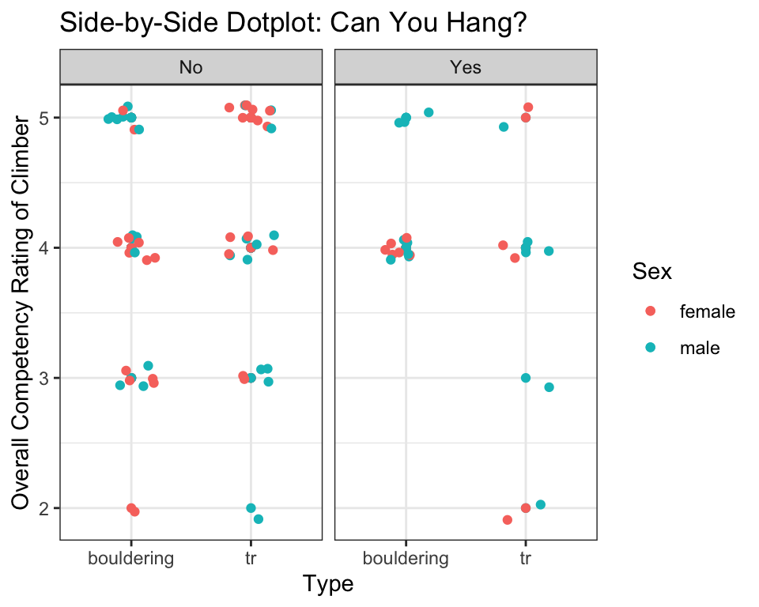

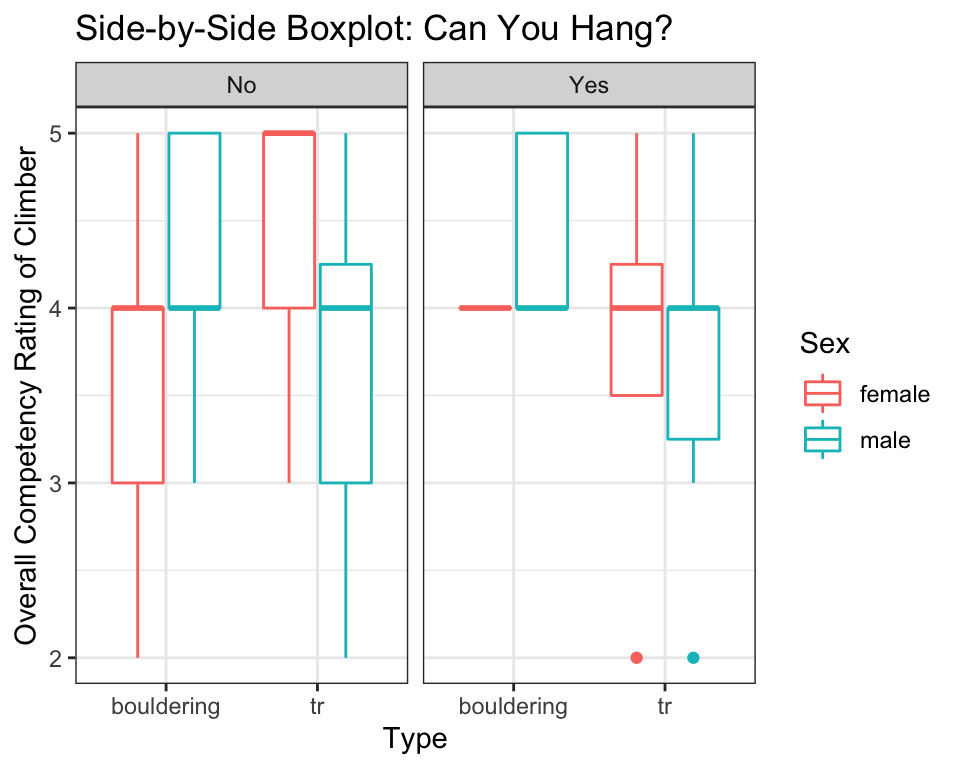

```r
# anova data set
simple_data <- mp2data[-c(1)]
write_csv(simple_data, "simple_data.csv")
```

**ANOVA Hypothesis**

$H_0:$ Men are perceived as physically stronger, regardless of the type of climbing. Therefore, the interaction between type of climbing (either bouldering or top roping) and sex does not affect a person’s perception of a climber’s strength. Only the sex of the climber is significant.

$H_A:$ The interaction between type of climbing and sex does affect a person’s perception of a climber’s strength. Only looking at sex is not a significant indicator of a climber’s perceived strength and ability.

```r
#ANOVA
ANOVA_test <- lm(Rating ~ Type * Sex, data = simple_data)
anova(ANOVA_test)
```

|  | Df | Sum Sq | Mean Sq | F value | Pr(>F) |
| --- | --- | --- | --- | --- | --- |
| Type | 1 | 0.0093567 | 0.0093567 | 0.0139868 | 0.9061865 |
| Sex | 1 | 0.0106719 | 0.0106719 | 0.0159528 | 0.8998431 |
| Type:Sex | 1 | 4.6957190 | 4.6957190 | 7.0193281 | 0.0099050 |
| Residuals | 72 | 48.1658312 | 0.6689699 | NA | NA |

```r
pander(anova(ANOVA_test))
```

Analysis of Variance Table

|  | Df | Sum Sq | Mean Sq | F value | Pr(>F) |
| --- | --- | --- | --- | --- | --- |
| **Type** | 1 | 0.009357 | 0.009357 | 0.01399 | 0.9062 |
| **Sex** | 1 | 0.01067 | 0.01067 | 0.01595 | 0.8998 |
| **Type:Sex** | 1 | 4.696 | 4.696 | 7.019 | 0.009905 |
| **Residuals** | 72 | 48.17 | 0.669 | NA | NA |

After looking at ANOVA output, we see that sex alone (p = 0.9) is not a significant predictor of a climber’s perceived strength. In fact, the interaction between type of climbing and sex (p = 0.01) is statistically significant. Therefore, we reject the null hypothesis and conclude that the interaction between type of climbing and sex is statistically significant predictor of a climber’s perceived stength and ability.

# Residual Analysis

*Check conditions on the residuals.*

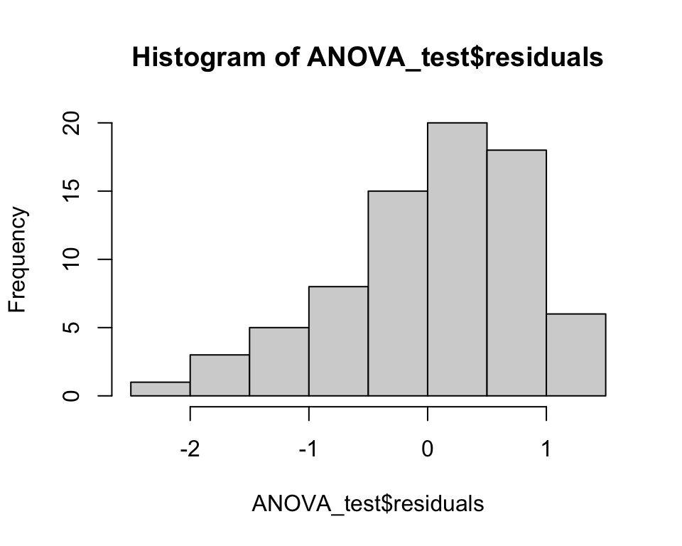

```r
hist(ANOVA_test$residuals)
```

The histogram of the residuals appears to follow a slightly normal distribution and for the sake of this exercise we will assume the condition of normality is met.

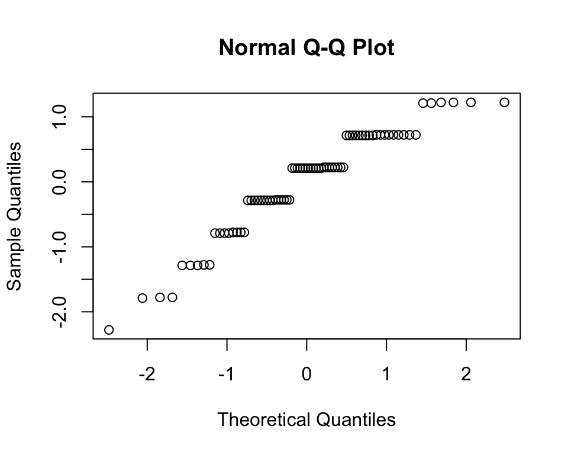

```r
qqnorm(ANOVA_test$residuals)
```

The normal Q-Q Plot appears to be relatively linear, so we will assume the condition of normality has been met.

# Equal Variance

```r
favstats(Rating ~ Sex|Type, data = simple_data)
```

| Type | min | Q1 | median | Q3 | max | mean | sd | n | missing |
| --- | --- | --- | --- | --- | --- | --- | --- | --- | --- |
| female.bouldering | 2 | 3.50 | 4.0 | 4 | 5 | 3.789474 | 0.7132825 | 19 | 0 |
| male.bouldering | 3 | 4.00 | 4.0 | 5 | 5 | 4.285714 | 0.7171372 | 21 | 0 |
| female.tr | 2 | 4.00 | 4.5 | 5 | 5 | 4.277778 | 0.8947925 | 18 | 0 |
| male.tr | 2 | 3.00 | 4.0 | 4 | 5 | 3.777778 | 0.9428090 | 18 | 0 |
| bouldering | 2 | 4.00 | 4.0 | 5 | 5 | 4.050000 | 0.7493587 | 40 | 0 |
| tr | 2 | 3.75 | 4.0 | 5 | 5 | 4.027778 | 0.9407022 | 36 | 0 |

The largest standard deviation (SD = 0.94) is not three times larger than the smallest standard deviation (SD = 0.71). Therefore Fisher’s S assumption is met.

# Assessing Third Factor: Prior Knowledge of Climbing

$H_0:$: The factor of prior knowledge of the sport of climbing will not have a statistically significant effect on the perceived strength of climbers of different sexes and on different types of climbs.

$H_A:$ The factor of prior knowledge of the sport of climbing will have a statistically significant effect on the perceived strength of climbers of different sexes and on different types of climbs.

```r
# second ANOVA
mod2 <- lm(Rating ~ Type * Sex * Climber, data = simple_data)
anova(mod2)
```

|  | Df | Sum Sq | Mean Sq | F value | Pr(>F) |
| --- | --- | --- | --- | --- | --- |
| Type | 1 | 0.0093567 | 0.0093567 | 0.0137926 | 0.9068562 |
| Sex | 1 | 0.0106719 | 0.0106719 | 0.0157313 | 0.9005577 |
| Climber | 1 | 0.0639173 | 0.0639173 | 0.0942192 | 0.7598183 |
| Type:Sex | 1 | 4.6714173 | 4.6714173 | 6.8860388 | 0.0107173 |
| Type:Climber | 1 | 1.4771647 | 1.4771647 | 2.1774577 | 0.1446613 |
| Sex:Climber | 1 | 0.0700354 | 0.0700354 | 0.1032377 | 0.7489639 |
| Type:Sex:Climber | 1 | 0.4485211 | 0.4485211 | 0.6611556 | 0.4189902 |
| Residuals | 68 | 46.1304945 | 0.6783896 | NA | NA |

```r
pander(anova(mod2))
```

Analysis of Variance Table

|  | Df | Sum Sq | Mean Sq | F value | Pr(>F) |
| --- | --- | --- | --- | --- | --- |
| **Type** | 1 | 0.009357 | 0.009357 | 0.01379 | 0.9069 |
| **Sex** | 1 | 0.01067 | 0.01067 | 0.01573 | 0.9006 |
| **Climber** | 1 | 0.06392 | 0.06392 | 0.09422 | 0.7598 |
| **Type:Sex** | 1 | 4.671 | 4.671 | 6.886 | 0.01072 |
| **Type:Climber** | 1 | 1.477 | 1.477 | 2.177 | 0.1447 |
| **Sex:Climber** | 1 | 0.07004 | 0.07004 | 0.1032 | 0.749 |
| **Type:Sex:Climber** | 1 | 0.4485 | 0.4485 | 0.6612 | 0.419 |
| **Residuals** | 68 | 46.13 | 0.6784 | NA | NA |

H_0 remains

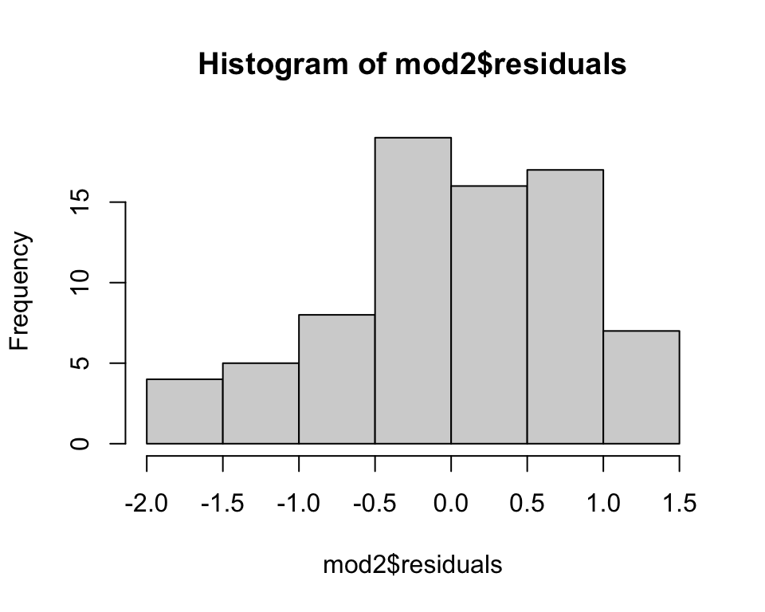

```r
hist(mod2$residuals)
```

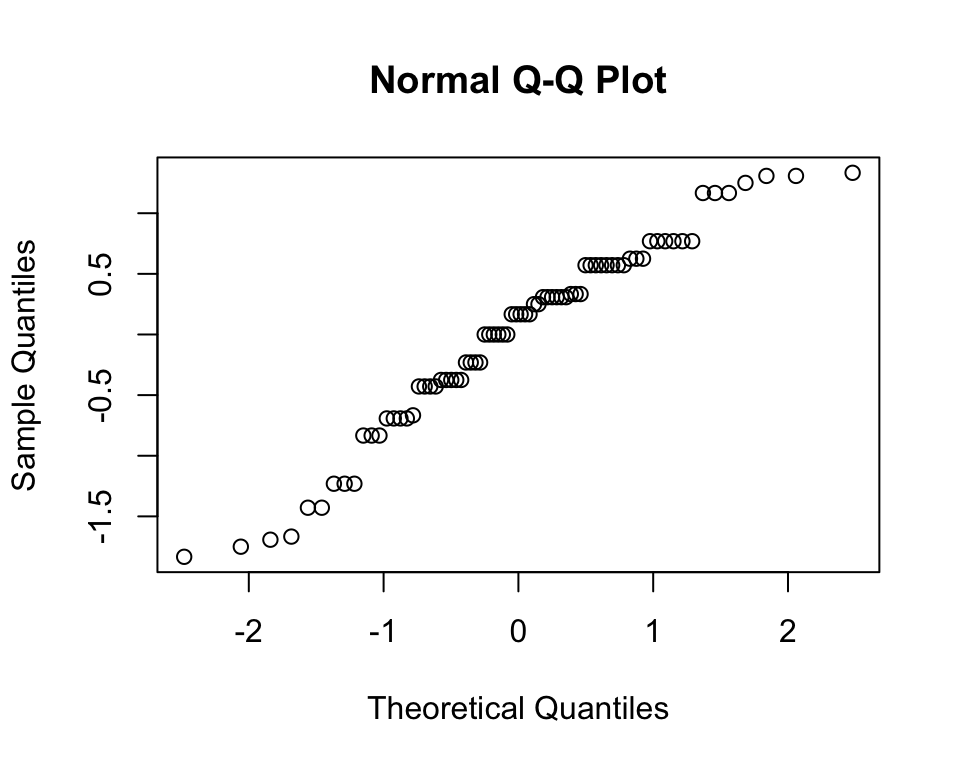

```r
qqnorm(mod2$residuals)
```

Plots look decent

*How to calculate favstats on this model? Use manual SD calculations instead

```r
simple_data %>%
  group_by(Type, Sex, Climber) %>%
  summarise(
    sd = sd(Rating)
  )
```

| Type | Sex | Climber | sd |
| --- | --- | --- | --- |
| bouldering | female | No | 0.8548504 |
| bouldering | female | Yes | 0.0000000 |
| bouldering | male | No | 0.8320503 |
| bouldering | male | Yes | 0.5175492 |
| tr | female | No | 0.7559289 |
| tr | female | Yes | 1.2583057 |
| tr | male | No | 0.9374369 |
| tr | male | Yes | 1.0327956 |